# Fixing Employee Happiness at TechTrend Innovations - Assignment 04

## Task 2: Exploring Cyclist Patterns for CycleWorks’ Ad Campaign

Ms. Sarah Speed at **CycleWorks** needs you to uncover when the Fremont Bridge is buzzing with cyclists to time her ads perfectly. Your analysis of daily cyclist counts and Seattle’s weather will reveal the best days for maximum impact.

- Create visualizations (e.g., line or bar charts) to show daily cyclist trends across days of the week and seasons.
- Compare cyclist counts in the east and west directions to identify the busier path for ad placement.
- Calculate correlations between `TotalCyclists` and weather variables (TAVG, PRCP, AWND).

```python
df_final["DayOfWeek"].unique()
```

```
array(['Tuesday', 'Wednesday', 'Thursday', 'Friday', 'Saturday', 'Sunday',
       'Monday'], dtype=object)
```

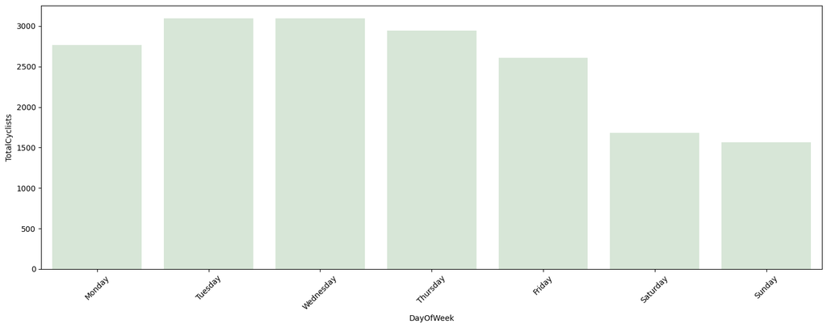

```python
plt.figure(figsize=(15,6))
order=["Monday","Tuesday", "Wednesday", "Thursday", "Friday" , "Saturday", "Sunday"]
sns.barplot(x="DayOfWeek", y = "TotalCyclists", data = df_final, errorbar = None,order=order,color="#D5E8D4")
plt.xticks(rotation=45)
plt.tight_layout()
plt.show()
```

🗣 We see that on weekends the number of cyclists clearly decreases, and midweek days have the highest density and seem to be the most suitable days.

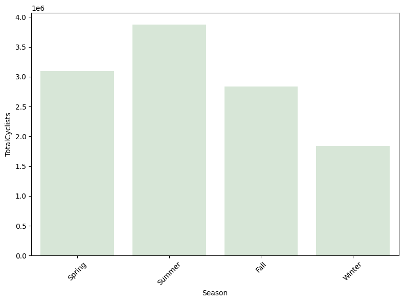

```python
plt.figure(figsize=(8,6))
order=["Spring", "Summer", "Fall" , "Winter"]
sns.barplot(x="Season", y = "TotalCyclists", data = df_final, errorbar = None, estimator=sum,order=order,color="#D5E8D4")
plt.xticks(rotation=45)
plt.tight_layout()
plt.show()
```

🗣 We also have the highest density of cyclists in the summer and the lowest in the winter.

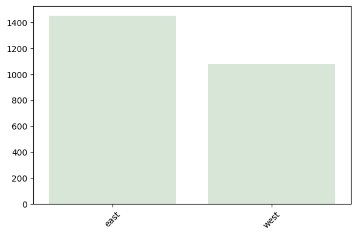

```python
# Write your answer here:
import matplotlib.pyplot as plt
plt.figure(figsize=(6,4))
east_total = df_final["CyclistEast"].mean()
west_total = df_final["CyclistWest"].mean()
sns.barplot(x=["east","west"],y=[east_total,west_total],color='#D5E8D4')
plt.xticks(rotation=45)
plt.tight_layout()
plt.show()
```

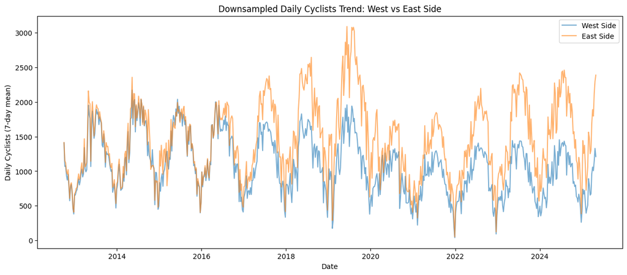

```python
#To simplify the chart and make it easier to see, we sampled part of the data and considered the average of the week instead of each day of the week.
df_sampled = df_final.select_dtypes(include='number').set_index(df_final['Date']).resample('7D').mean().reset_index()
plt.figure(figsize=(15,6))
sns.lineplot(x='Date', y='CyclistWest', data=df_sampled, label='West Side', alpha=0.6)
sns.lineplot(x='Date', y='CyclistEast', data=df_sampled, label='East Side', alpha=0.6)
plt.ylabel('Daily Cyclists (7-day mean)')
plt.title('Downsampled Daily Cyclists Trend: West vs East Side')
plt.legend()
plt.show()
```

🗣 Also, in the time series chart, we see that initially the difference between the West and the East was very small and almost equal, and over time, the number of cyclists in the West has decreased and fluctuated greatly, while the number of cyclists in the East has increased and decreased with great fluctuations, but in general, there have always been more cyclists than in the West, and this difference has been significant since 2017.

```python
weather_cols = ['TAVG', 'PRCP', 'AWND']
corrs = df_final[['TotalCyclists'] + weather_cols].corr()
print("Correlation matrix:")
print(corrs)
```

```
Correlation matrix:
               TotalCyclists      TAVG      PRCP      AWND
TotalCyclists       1.000000  0.102343  0.018037 -0.061293
TAVG                0.102343  1.000000 -0.169927 -0.120423
PRCP                0.018037 -0.169927  1.000000  0.269212
AWND               -0.061293 -0.120423  0.269212  1.000000
```

🗣 We see that the Correlation between weather scales and the number of cyclists is very small, but it would be better to investigate further how the data is distributed based on these features.

## Task 3: Grouping Days for CycleWorks’ Targeted Ad Strategy

Ms. Sarah Speed at **CycleWorks** wants to know which types of days—busy sunny ones or quiet rainy ones—are best for her ad campaign on the Fremont Bridge. Your clustering will group days to guide her strategy for the Seattle Bike Expo.

- Select a clustering algorithm (e.g., K-Means or DBSCAN) to group days based on `TotalCyclists` and weather variables (TAVG, PRCP, AWND).
- Interpret the clusters to identify patterns (e.g., high-traffic sunny days vs. low-traffic rainy days).
- Visualize the clusters (e.g., scatter plots or Elbow plot) to show day groupings.

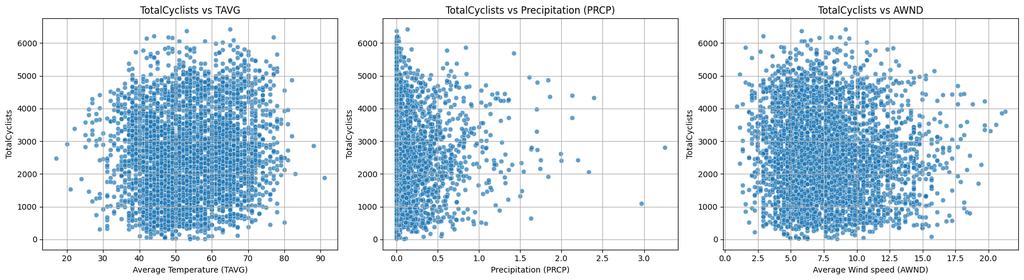

```python
import matplotlib.pyplot as plt
import seaborn as sns

plt.figure(figsize=(18,5))

# 1. TotalCyclists vs TAVG
plt.subplot(1, 3, 1)
sns.scatterplot(data=df_final, x='TAVG', y='TotalCyclists', alpha=0.7)
plt.title('TotalCyclists vs TAVG')
plt.xlabel('Average Temperature (TAVG)')
plt.ylabel('TotalCyclists')
plt.grid(True)

# 2. TotalCyclists vs PRCP
plt.subplot(1, 3, 2)
sns.scatterplot(data=df_final, x='PRCP', y='TotalCyclists', alpha=0.7)
plt.title('TotalCyclists vs Precipitation (PRCP)')
plt.xlabel('Precipitation (PRCP)')
plt.ylabel('TotalCyclists')
plt.grid(True)

# 3. TotalCyclists vs AWND
plt.subplot(1, 3, 3)
sns.scatterplot(data=df_final, x='AWND', y='TotalCyclists', alpha=0.7)
plt.title('TotalCyclists vs AWND')
plt.xlabel('Average Wind speed (AWND)')
plt.ylabel('TotalCyclists')
plt.grid(True)

plt.tight_layout()
plt.show()
```

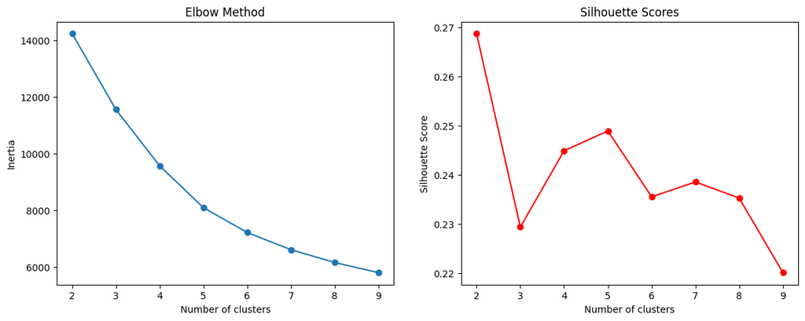

```python
import pandas as pd
from sklearn.preprocessing import StandardScaler
from sklearn.cluster import KMeans
import matplotlib.pyplot as plt
import seaborn as sns
from sklearn.metrics import silhouette_score

features = ['TotalCyclists', 'TAVG', 'PRCP', 'AWND']
X = df_final[features].copy()
scaler = StandardScaler()
X_scaled = scaler.fit_transform(X)

# Determining the number of clusters using tools such as Elbow and Silhouette
K_range = range(2, 10)
inertia = []
silhouette_scores = []

for k in K_range:
    kmeans = KMeans(n_clusters=k, n_init=10, random_state=42)
    kmeans.fit(X_scaled)
    inertia.append(kmeans.inertia_)
    silhouette_scores.append(silhouette_score(X_scaled, kmeans.labels_))

fig, (ax1, ax2) = plt.subplots(1, 2, figsize=(14, 5))
ax1.plot(K_range, inertia, marker='o')
ax1.set_title('Elbow Method')
ax1.set_xlabel('Number of clusters')
ax1.set_ylabel('Inertia')

ax2.plot(K_range, silhouette_scores, marker='o', color='red')
ax2.set_title('Silhouette Scores')
ax2.set_xlabel('Number of clusters')
ax2.set_ylabel('Silhouette Score')

plt.show()
```

```python
#Since the Elbow method does not exhibit a clear inflection point and the inertia decreases smoothly without a significant drop, selecting the optimal number of clusters based on the Silhouette Score is more reasonable.
#In this case, k = 2 yields the highest silhouette score, indicating the best cluster separation, and is therefore chosen as the optimal number of clusters.
best_k = 2
```

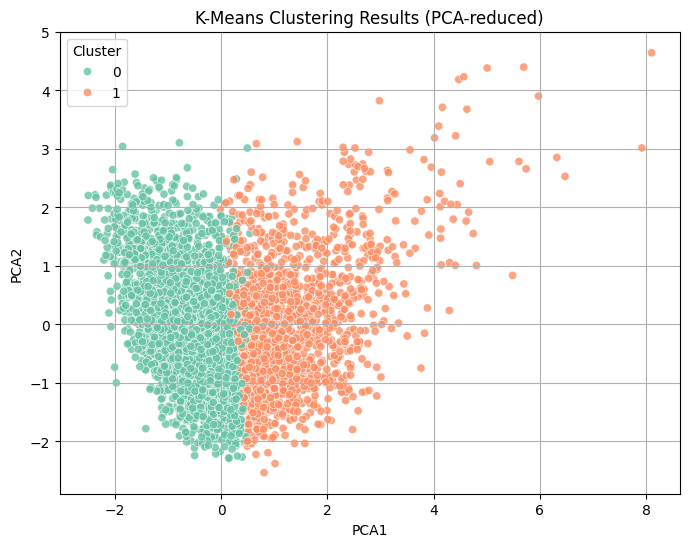

```python
from sklearn.preprocessing import StandardScaler
from sklearn.cluster import KMeans

kmeans = KMeans(n_clusters=best_k, random_state=42)
clusters = kmeans.fit_predict(X_scaled)
df_final['Cluster'] = clusters
from sklearn.decomposition import PCA

pca = PCA(n_components=2)
X_pca = pca.fit_transform(X_scaled)

df_final['PCA1'] = X_pca[:, 0]
df_final['PCA2'] = X_pca[:, 1]
plt.figure(figsize=(8,6))
sns.scatterplot(data=df_final, x='PCA1', y='PCA2', hue='Cluster', palette='Set2', alpha=0.8)
plt.title('K-Means Clustering Results (PCA-reduced)')
plt.grid(True)
plt.show()
```

```python
df_final.groupby('Cluster')[['TAVG', 'PRCP', 'AWND', 'TotalCyclists']].mean()
```

| Cluster | TAVG | PRCP | AWND | TotalCyclists |
| --- | --- | --- | --- | --- |
| 0 | 57.054142 | 0.028329 | 6.258388 | 2631.543555 |
| 1 | 47.090777 | 0.286959 | 10.646359 | 2332.146999 |

🗣 An examination of the clustering results shows that the data are mostly divided into two fairly similar groups. The first cluster (Cluster 0) represents days with relatively higher temperatures, lower precipitation, and lower wind speeds—conditions that lead to the highest number of cyclists recorded. In contrast, the second cluster (Cluster 1) reflects days with lower temperatures, more precipitation, and higher wind speeds, in which the average number of cyclists is lower. However, the distinction between these two clusters is slight, and the low Silhouette score indicates that the clustering is not very clear or distinct. This suggests that cyclist traffic behavior is more continuous and gradual in nature, rather than being fully separable into two completely distinct groups.

## Task 4: Predicting Cyclist Traffic for CycleWorks’ Ad Campaign

Ms. Sarah Speed at **CycleWorks** needs you to predict when the Fremont Bridge will be packed with cyclists to schedule ads for maximum impact at the Seattle Bike Expo. Your model will forecast daily cyclist counts to ensure ads hit the busiest days.

- Choose a predictive model (e.g., linear regression or Random Forest) to forecast `TotalCyclists`.
- Use features like weather variables (TAVG, PRCP, AWND) and temporal features (DayOfWeek, Month, Season).
- Split data into training and testing sets and evaluate the model with metrics like RMSE or R².
- Analyze feature importance to identify key predictors (e.g., temperature or day of week).

```python
#feature selection with
from sklearn.ensemble import RandomForestRegressor
from sklearn.feature_selection import RFE
import pandas as pd
X = df_final[["TAVG", "PRCP", "AWND","DayOfWeek", "Month", "Season"]]
X = pd.get_dummies(X, drop_first=True)
y = df_final['TotalCyclists']
#RandomForest for estimating
rf = RandomForestRegressor(n_estimators=100, random_state=42)
#using RFE for feature selecting
rfe = RFE(estimator=rf, n_features_to_select=8)
rfe.fit(X, y)
selected_cols = X.columns[rfe.support_]
importances = rfe.estimator_.feature_importances_
importance_series = pd.Series(importances, index=selected_cols).sort_values(ascending=False)
print(importance_series)
```

```
Season_Winter         0.190162
AWND                  0.174459
TAVG                  0.144813
DayOfWeek_Saturday    0.111958
Season_Summer         0.108652
DayOfWeek_Sunday      0.104507
Month                 0.091529
PRCP                  0.073920
dtype: float64
```

🗣 The model appears to be most influenced by the winter season, supported by average temperature and wind speed as significant factors affecting cyclist density. Saturday and Sunday are also identified as important features, consistent with previous descriptive analyses. Additionally, summer shows notable influence.

```python
# Since the model appears nonlinear and complex, using Random Forest instead of Linear Regression is preferable.
from sklearn.metrics import mean_squared_error, r2_score
from sklearn.model_selection import train_test_split
#X = df_final[["TAVG", "PRCP", "AWND","DayOfWeek", "Month", "Season"]]
#y = df_final['TotalCyclists']
X_train, X_test, y_train, y_test = train_test_split(X, y, test_size=0.2, random_state=42)
rf_model = RandomForestRegressor(n_estimators=100, random_state=42)
rf_model.fit(X_train, y_train)
y_pred = rf_model.predict(X_test)
rmse = np.sqrt(mean_squared_error(y_test, y_pred))
r2 = r2_score(y_test, y_pred)
print(f"RMSE: {rmse:.2f}")
print(f"R²: {r2:.3f}")
```

```
RMSE: 845.41
R²: 0.561
```

🗣 The RMSE value of 845.41 indicates a moderate prediction error relative to the variability in the data. Combined with an R² value below 0.6, this suggests that the model explains some, but not all, of the underlying patterns.

## Task 5: Delivering CycleWorks’ Winning Ad Strategy

Ms. Sarah Speed at **CycleWorks** is ready for your insights to launch a show-stopping ad campaign at the Seattle Bike Expo. Your findings from cyclist traffic and weather patterns will guide when and where to place ads on the Fremont Bridge.

- Summarize key patterns in cyclist traffic (e.g., busiest days or seasons) and weather impacts.
- Highlight clustering results (e.g., types of days) and predictive model performance with key predictors.
- Provide recommendations (e.g., target sunny summer days or busier bridge side, offer rainy-day discounts).
- Present a structured report with visualizations (e.g., charts, tables) summarizing findings and ad suggestions.

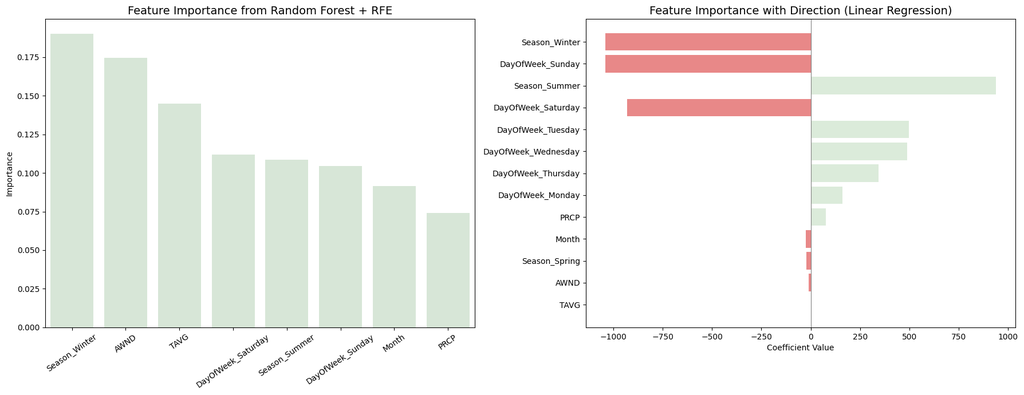

```python
import matplotlib.pyplot as plt
import seaborn as sns
import pandas as pd
from sklearn.linear_model import LinearRegression

importance_df = importance_series.reset_index()
importance_df.columns = ['Feature', 'Importance']
order = importance_df.sort_values(by='Importance', ascending=False)['Feature']

lr = LinearRegression()
lr.fit(X, y)
coefficients = pd.Series(lr.coef_, index=X.columns)
coefficients = coefficients.reindex(coefficients.abs().sort_values(ascending=False).index)
colors = coefficients.apply(lambda x: "#D5E8D4" if x > 0 else "#E57373")

fig, (ax1, ax2) = plt.subplots(1, 2, figsize=(18, 7))

sns.barplot(x='Feature', y='Importance', data=importance_df, order=order, color="#D5E8D4", ax=ax1)
ax1.set_title('Feature Importance from Random Forest + RFE', fontsize=14)
ax1.set_xlabel('')
ax1.set_ylabel('Importance')
ax1.tick_params(axis='x', rotation=35)

bars = ax2.barh(coefficients.index, coefficients.values, color=colors, alpha=0.85)
ax2.set_title('Feature Importance with Direction (Linear Regression)', fontsize=14)
ax2.set_xlabel('Coefficient Value')
ax2.axvline(x=0, color='gray', linewidth=0.8)
ax2.invert_yaxis()
plt.tight_layout()
plt.show()
```

🗣 **Based on a comprehensive analysis of cyclist traffic data on the Fremont Bridge and corresponding weather conditions, the following key insights are provided to optimize the targeting of your marketing campaign:**

**1. Cyclist Behavior Patterns:**

- The first group includes days with milder weather (higher temperature, lower precipitation and wind), seeing higher cyclist counts.
- The second group comprises colder, windier, and wetter days, resulting a reduction in cycling activity.

However, the distinction between these groups is gradual (not stark), and overall traffic tends to change dynamically and progressively rather than in sharp steps.

**2. Feature Importance in Traffic Prediction:**

**3. Actionable Recommendations:**